# Part 1

Eric Langowski

# Introduction

The Detroit housing market has experienced historic levels of foreclosures, disinvestment, and demolitions. Over 1 in 4 properties has been foreclosed due to property tax foreclosure since 2011 and many of these foreclosures were due to inaccurate, inflated assessments. These assessments remain problematic even after the City of Detroit undertook its first citywide reassessment in over 60 years which became effective in 2017.

Since the beginning of the coronavirus pandemic, tax foreclosures have been halted and assessments have become more accurate. Detroit’s housing market has begun to recover with some neighborhoods even gentrifying. Yet, the system remains inequitable especially for low-income homeowners of color.

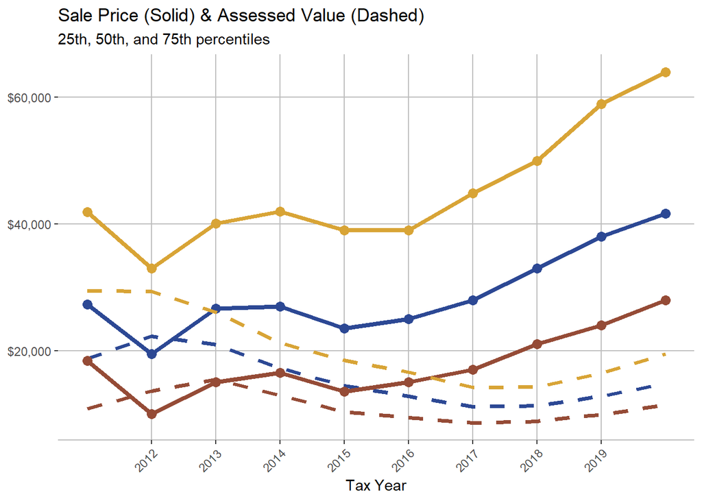

```r
output[[2]]
```

This analysis focuses on single family homes (class 401) which were taxable, sold for more than $2000, and marked as arm’s length by the assessor. Additionally, using the `cmfproperty` package, the IAAO arm’s length standard was applied to the data. This will present a conservative picture of the housing market in Detroit. Note that homes in Detroit as supposed to be assessed at most at 50% of their fair market value.

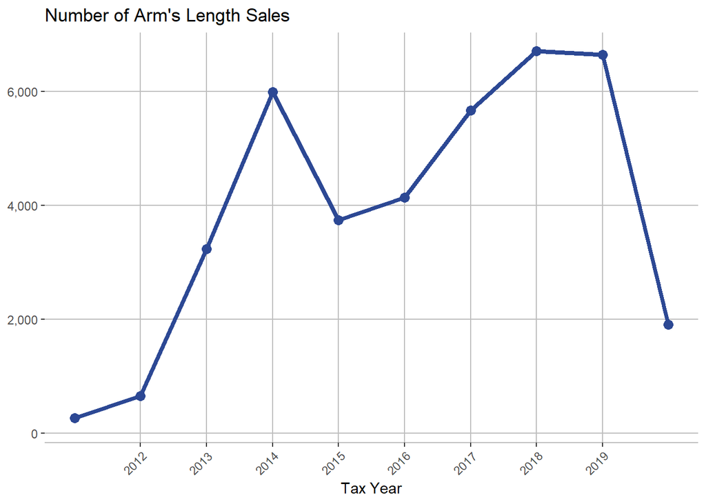

```r
output[[1]]
```

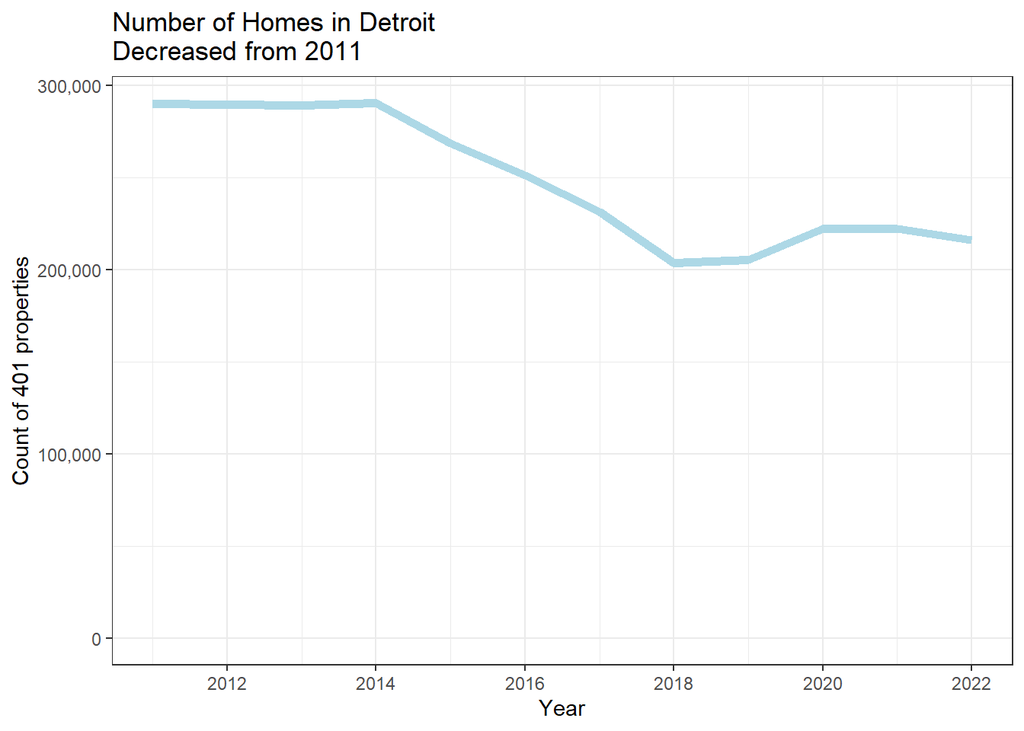

```r
homes_counts <- assessments %>% filter(propclass == 401) %>%
  count(year)

ggplot(homes_counts, aes(x=year, y=n)) +
  geom_line(color='light blue', size=2) +
  scale_y_continuous(labels=scales::comma, limit=c(0, NA)) +
  scale_x_continuous(breaks=scales::pretty_breaks()) +
  labs(x='Year', y='Count of 401 properties', title='Number of Homes in Detroit \nDecreased from 2011')
```

# Sales Ratio Analysis

```r
iaao <- cmfproperty::iaao_graphs(stats=stats, ratios=ratios, min_reporting_yr = 2012, max_reporting_yr = 2019, jurisdiction_name = 'Detroit')
```

For 2019, the COD in Detroit was 42.57 which **did not meet** the IAAO standard for uniformity.

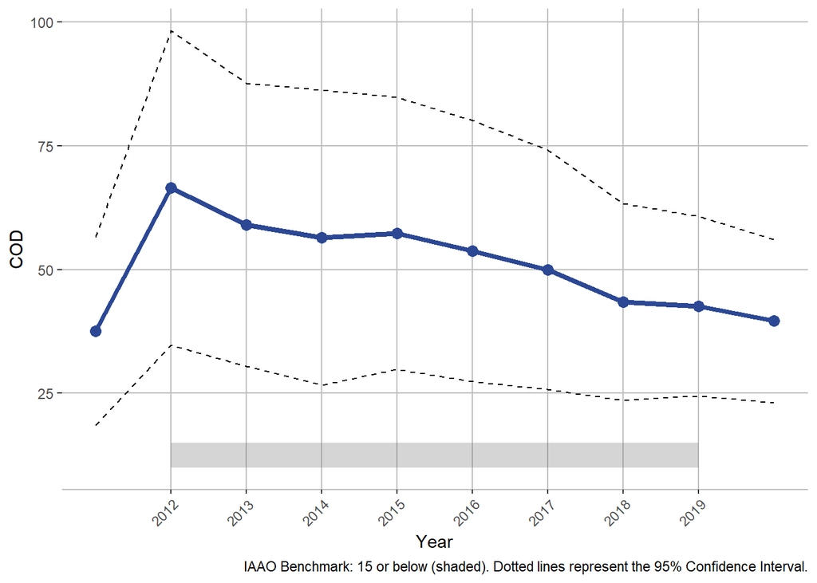

```r
iaao[[2]]
```

In 2019, the PRD in Detroit, was 1.325 which **does not meet** the IAAO standard for vertical equity.

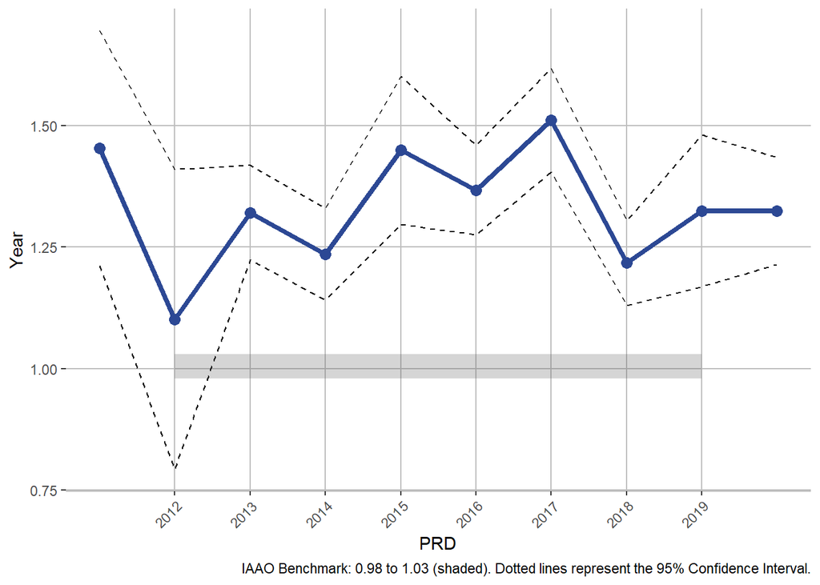

```r
iaao[[4]]
```

In 2019, the PRB in Detroit was -0.354 which indicates that sales ratios decrease by 35.4% when home values double. This **does not meet** the IAAO standard.

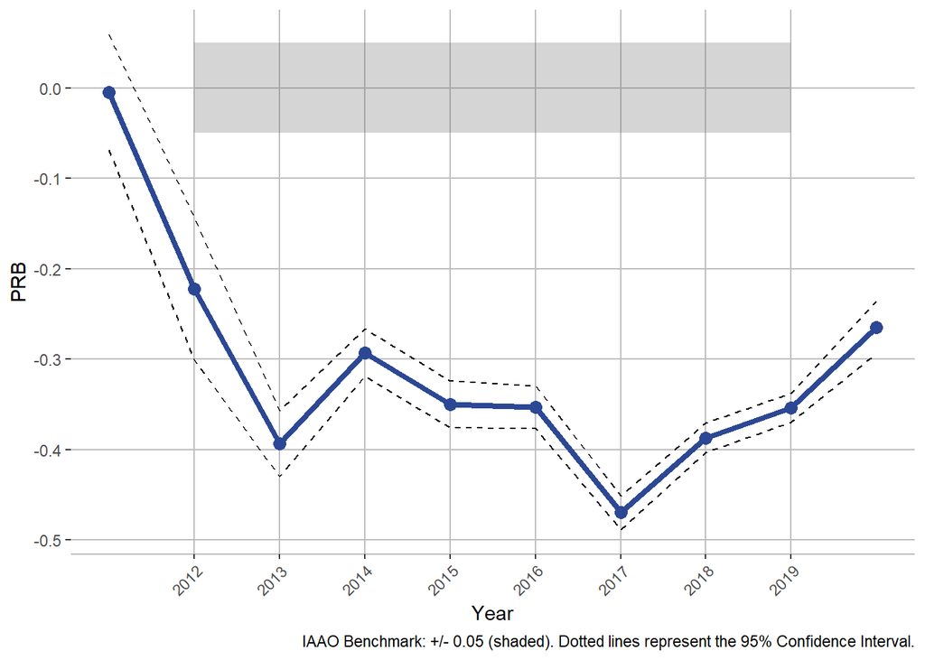

```r
iaao[[6]]
```

```r
bs <- cmfproperty::binned_scatter(ratios = ratios, min_reporting_yr = 2012, max_reporting_yr = 2019, jurisdiction_name = 'Detroit')
```

In 2019, the most expensive homes (the top decile) were assessed at 22.9% of their value and the least expensive homes (the bottom decile) were assessed at 72.6%. In other words, the least expensive homes were assessed at **3.18 times** the rate applied to the most expensive homes. Across our sample from 2012 to 2019, the most expensive homes were assessed at 27.1% of their value and the least expensive homes were assessed at 111.8%, which is **4.12 times** the rate applied to the most expensive homes.

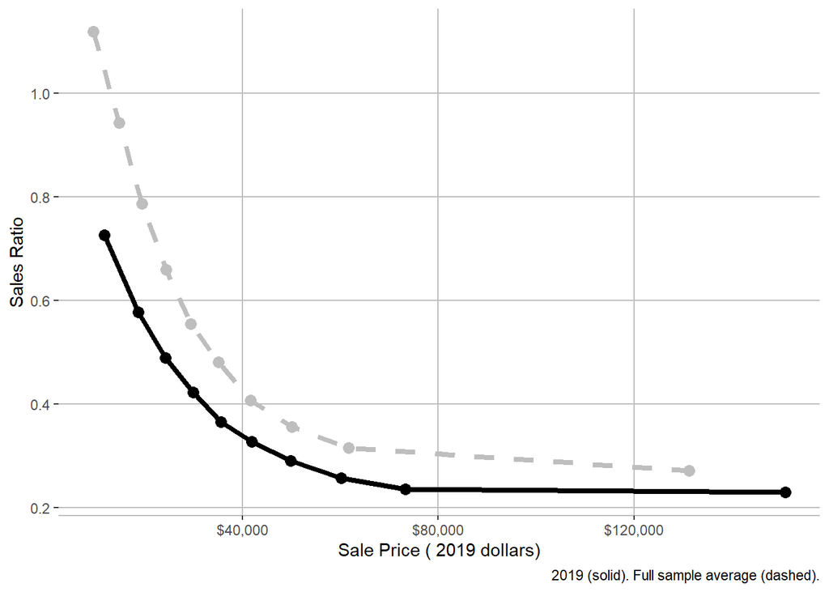

```r
bs[[2]]
```

# Initial Relationships

## Property Sales

```r
ratios_chars <-
  ratios %>%
  left_join(parcels, by=c('parcel_num'='parcel_number')) %>%
  mutate(year = as.character(TAX_YEAR))

lm_model <-
  parsnip::linear_reg() %>%
  set_engine("lm") %>%
  set_mode('regression')

first_recipe <- recipe(sale_price ~
                         ecf + total_square_footage +
                         year, data=ratios_chars) %>%
  step_unknown(all_nominal_predictors()) %>%
  step_dummy(all_nominal_predictors())

first_workflow <-
  workflow() %>%
  add_model(lm_model) %>%
  add_recipe(first_recipe)

model_fit <- first_workflow %>%
  fit(data=ratios_chars)

model_fit %>% glance()
```

| r.squared | adj.r.squared | sigma | statistic | p.value | df | logLik | AIC | BIC | deviance | df.residual | nobs |
| --- | --- | --- | --- | --- | --- | --- | --- | --- | --- | --- | --- |
| 0.17522 | 0.1698458 | 74918.87 | 32.6035 | 0 | 252 | -492031 | 984570.1 | 986746.7 | 2.170709e+14 | 38674 | 38927 |

```r
model_fit %>% tidy()
```

| term | estimate | std.error | statistic | p.value |
| --- | --- | --- | --- | --- |
| (Intercept) | 1.967176e+04 | 5.923429e+03 | 3.321008e+00 | 8.977587e-04 |
| total_square_footage | 4.053851e+00 | 2.760062e-01 | 1.468754e+01 | 1.048486e-48 |
| ecf_X0036A | -2.950457e+04 | 7.498494e+04 | -3.934733e-01 | 6.939721e-01 |
| ecf_X0038A | 2.447619e+03 | 3.364528e+04 | 7.274778e-02 | 9.420072e-01 |
| ecf_X0039A | -2.074166e+04 | 4.955369e+03 | -4.185695e+00 | 2.849231e-05 |
| ecf_X0039C | -1.017922e+04 | 8.150089e+03 | -1.248970e+00 | 2.116836e-01 |
| ecf_X0039F | 1.140312e+04 | 1.958841e+04 | 5.821358e-01 | 5.604786e-01 |
| ecf_X0040A | 1.398472e+04 | 3.452103e+03 | 4.051072e+00 | 5.108296e-05 |
| ecf_X0040B | 3.047663e+03 | 2.667237e+04 | 1.142629e-01 | 9.090300e-01 |
| ecf_X0040D | 1.609262e+04 | 1.014791e+04 | 1.585806e+00 | 1.127915e-01 |

[output cut: 245 more lines]

## Foreclosures

```r
foreclosures <- tbl(con, 'foreclosures') %>%
  collect() %>%
  select(-prop_addr) %>%
  pivot_longer(!prop_parcelnum, names_to='year', values_to='foreclosed') %>%
  filter(!is.na(foreclosed)) %>%
  distinct()

foreclosures_chars <-
  assessments %>%
  mutate(year = as.character(year)) %>%
  filter(propclass == 401) %>%
  left_join(foreclosures, by=c('PARCELNO'='prop_parcelnum', 'year')) %>%
  left_join(parcels %>% select(parcel_number, total_square_footage, year_built, zip_code), by=c('PARCELNO'='parcel_number')) %>%
  mutate(foreclosed = replace_na(foreclosed, 0),
         foreclosed = as.factor(foreclosed),
         zip_code = as.factor(zip_code))

glm_model <-
  parsnip::logistic_reg() %>%
  set_engine("glm") %>%
  set_mode('classification')

second_recipe <- recipe(foreclosed ~
                         total_square_footage + year_built + zip_code,
                        data=foreclosures_chars) %>%
  step_unknown(all_nominal_predictors()) %>%
  step_dummy(all_nominal_predictors())

second_workflow <-
  workflow() %>%
  add_model(glm_model) %>%
  add_recipe(second_recipe)

model_fit <- second_workflow %>%
  fit(data=foreclosures_chars %>% slice_sample(n=10000))

model_fit %>% glance()
```

| null.deviance | df.null | logLik | AIC | BIC | deviance | df.residual | nobs |
| --- | --- | --- | --- | --- | --- | --- | --- |
| 2152.108 | 8289 | -1046.726 | 2167.453 | 2427.297 | 2093.453 | 8253 | 8290 |

```r
model_fit %>% tidy()
```

| term | estimate | std.error | statistic | p.value |
| --- | --- | --- | --- | --- |
| (Intercept) | -1.775446e+01 | 6.387264e+02 | -2.779666e-02 | 0.977824329 |
| total_square_footage | -1.717911e-04 | 6.222679e-05 | -2.760726e+00 | 0.005767302 |
| year_built | 6.461754e-04 | 1.368028e-03 | 4.723408e-01 | 0.636683532 |
| zip_code_X45242.3706 | NA | NA | NA | NA |
| zip_code_X48200 | -8.186803e-01 | 2.059091e+03 | -3.975931e-04 | 0.999682767 |
| zip_code_X48201 | 5.656830e-02 | 2.036738e+03 | 2.777396e-05 | 0.999977840 |
| zip_code_X48202 | 1.286965e+01 | 6.387217e+02 | 2.014907e-02 | 0.983924452 |
| zip_code_X48203 | 1.372465e+01 | 6.387211e+02 | 2.148771e-02 | 0.982856605 |
| zip_code_X48204 | 1.376402e+01 | 6.387210e+02 | 2.154934e-02 | 0.982807443 |
| zip_code_X48204.3107 | NA | NA | NA | NA |

[output cut: 64 more lines]